# Spatial Data Analysis (450:320)

Class 13

## Today

- Attribute operations
- Geometric measurements
- Geometric operations
- Geometry operations

## Use `osmdata` to query some vectors

```r
library(dplyr)
library(osmdata) # has to install first

q <- opq(bbox = st_bbox(
    c(xmin = -74.448598, xmax = -74.429830,
      ymax = 40.532277, ymin = 40.518258), crs = st_crs(4326)))

# Building
buildings <- q %>%
  add_osm_feature(key = 'building') %>%
  osmdata_sf() %>% `[[`('osm_polygons') %>%
  filter(!is.na(name))

# Streets
streets <- q %>%
  add_osm_feature(key = 'highway') %>%
  osmdata_sf() %>% `[[`('osm_lines') %>%
  filter(!is.na(name))

# Trees
trees <- q %>%
  add_osm_feature(key = c('natural')) %>%
  osmdata_sf() %>% `[[`('osm_points')
```

## The data

```r
plot(buildings$geometry, col = "black")
plot(streets %>% st_geometry(), add = T, col = "brown")
plot(st_geometry(trees), pch = 20, add = TRUE, col = "darkgreen")
```

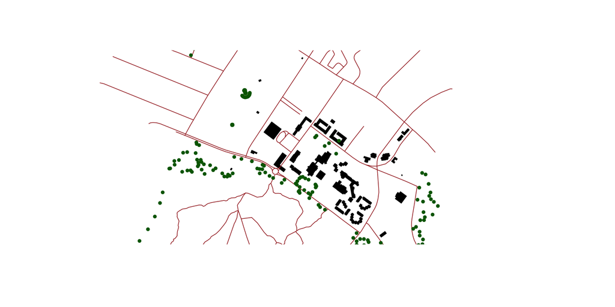

## Attribute operations

- `sf` is a data.frame, so all base R and `dplyr` syntax works on it. E.g.
  - subsetting
  - aggregation (group)
  - joining
- `st_drop_geometry()` to drop geometry column

## Practice 1

Tasks:

- Select out `streets` that are residential or path.
- Count the number of `streets` by types.

```
# A tibble: 6 × 2
  highway      count
  <chr>        <int>
1 path             8
2 residential     50
3 secondary       11
4 service          2
5 tertiary        19
6 unclassified     1
```

## Geometric measurements

- `st_area`
- `st_length`
- `st_distance`

## `st_area`

```r
buildings <- buildings %>%
    mutate(area = st_area(.)) %>%
    select(name, area)

head(buildings, 3) # Observe column area
```

```
Simple feature collection with 3 features and 2 fields
Geometry type: POLYGON
Dimension:     XY
Bounding box:  xmin: -74.43991 ymin: 40.5225 xmax: -74.4353 ymax: 40.52598
Geodetic CRS:  WGS 84
                             name           area                       geometry
221488774 Livingston Apartments C 4513.754 [m^2] POLYGON ((-74.4367 40.52485...
221488775 Livingston Apartments B 3942.836 [m^2] POLYGON ((-74.43778 40.5256...
251381247               Beck Hall 1841.321 [m^2] POLYGON ((-74.43915 40.5225...
```

```r
ggplot(buildings) +
    geom_sf(color = "black", aes(alpha = as.numeric(area))) +
    labs(alpha = "Area (m^2)") +
    theme_void()
```

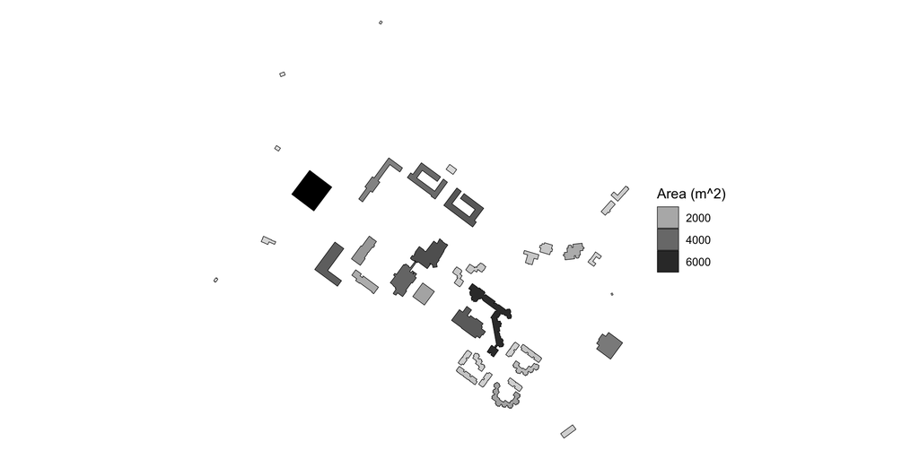

## Units

`units::set_units()`

```r
# Examples of usage
x <- 10 %>% units::set_units('km2')
x
```

```
10 [km^2]
```

```r
# Remove units
x <- units::set_units(x, NULL)
x
```

```
[1] 10
```

```r
buildings$area <- units::set_units(buildings$area, 'ha')
head(buildings, 3)
```

```
Simple feature collection with 3 features and 2 fields
Geometry type: POLYGON
Dimension:     XY
Bounding box:  xmin: -74.43991 ymin: 40.5225 xmax: -74.4353 ymax: 40.52598
Geodetic CRS:  WGS 84
                             name           area                       geometry
221488774 Livingston Apartments C 0.4513754 [ha] POLYGON ((-74.4367 40.52485...
221488775 Livingston Apartments B 0.3942836 [ha] POLYGON ((-74.43778 40.5256...
251381247               Beck Hall 0.1841321 [ha] POLYGON ((-74.43915 40.5225...
```

## Practice 2

`streets`:

- Calculate the length of each street in **km** and save to a new column “length” to `streets`.
- Calculate the average length by street types (in column highway).

`trees`: Calculate the distance between the first two tree in **miles**.

```
# A tibble: 6 × 2
  highway      avg_length
  <chr>              [km]
1 path              0.649
2 residential       0.285
3 secondary         0.122
4 service           0.165
5 tertiary          0.157
6 unclassified      0.486
```

## Geometric operations

- `st_centroid` (get the centroid of objects)
- `st_buffer` (add buffer to any objects)
- `st_coordinates` (get coordinates of objects)
- `st_simplify` (reduce the complexity of objects)
- `st_bbox` (get the bounding box of objects)

**Practice 3**

- Simplify the buildings and get the centroid of the them.
- Reproject streets to Albers Equal Area (EPSG:5070) and add a 10 meter buffer to them.
- Get the coordinates of trees.

## Geometry operations

- Clipping/overlapping
  - `st_intersection`
  - `st_difference` & `st_sym_difference`
  - `st_union`: return `sfc`

## Practice 4

```r
# Your building from osmdata
building_osm <- buildings %>% filter(name == '...')

# building polygon you created
building_mine <- ...

# try these operations
bld_itst <- st_intersection(building_mine, building_osm)
dif_osm_bld <- st_difference(building_osm, building_mine)
dif_bld_osm <- st_difference(building_mine, building_osm)
bld_union <- st_union(building_mine, building_osm)
bld_bbox <- st_bbox(bld_union) %>%
  st_as_sfc() %>% st_sf()

# plot the results and learn each function
plot(bld_bbox$geometry, col = 'lightblue')
plot(building_osm$geometry, border = "black", add = T)
plot(building_mine$geometry, border = "brown", add = T)

plot(dif_osm_bld$geometry, col = 'red', add = T)
plot(dif_bld_osm$geometry, col = 'blue', add = T)
plot(bld_itst$geometry, col = 'yellow', add = T)
```

## Homework

- No homework
- But please finish reading Unit2-Module1 and do all the practices (!!)